# Bays Theorm

Hussain Alsalman

1/22/2021

### BAYS THEORM

Inspector Ahmed arrives at the scene of a crime. The victim lies dead in the room and the inspector quickly finds the murder weapon,a Knife (K). The Butler (B) and Maid (M) are his main suspects. The inspector has a prior belief of 0.6 that the Butler is the murderer, and a prior belief of 0.2 that the Maid is the murderer. These probabilities are independent in the sense that p(B,M) =p(B)p(M). (It is possible that both the Butler and the Maid murdered the victim or neither).

The inspector’s prior criminal knowledge can be formulated mathematically as follows:

- domain(B) = domain(M) ={murderer,not murderer}
- domain(K) ={knife used,knife not used}
- p(B=murderer) = 0.6, p(M=murderer) = 0.2
- p(knife used| B=not murderer, M=not murderer) = 0.3
- p(knife used| B=not murderer, M=murderer)= 0.2
- p(knife used| B=murderer,M=not murderer) = 0.6
- p(knife used| B=murderer,M=murderer)= 0.1

### New evidance

The victim lies dead in the room and the inspector quickly finds the murder weapon, a Knife (K).

### Inspector Tasks

What is the probability that the Butler is the murderer? (Remember that it might be that neither is the murderer).

## Example: The probability Murder

[output not shown]

## Let’s review the Bayes Theorm again

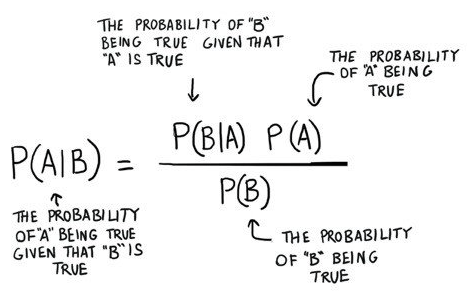

the probability that the butler is the murderer given that the knife is the crime weapon is as follows. m term represent both states of maid.

This is simply the conditional probability on Knife being used

$$P(B,m| K ) = \sum_m\frac{P(K,B,m)}{P(K)}$$
First we expand the nominator

$$P(K, B, m) = \sum_m {P(K | B, m ) * P(B, m)}$$

This is how our formula will look like

$$P(B,m| K ) = \sum_m \frac{P(K | B, m ) * P(B, m)}{P(K)}$$

Now, let’s expand the denominator

$$P(K) = \sum_b P(b) \sum_m P(K|b,m) * P(m)$$
## This could be simplified

This table helps us calculate the formula above.

[output not shown]

our final calculation will be the following

$$P(B,m| K ) = \frac{0.012+ 0.288} {0.412} = 0.728$$
Therefore the probability of the murderer being the butler give that the crime weapon is %72